# Random Forest Prediction Model for Smartphone App Downloads

## Data Preprocessing

Before building the model, we need to prepare the data. We will convert the target variable V8 to a factor and split the data into training and testing sets with a 50:50 ratio.

```r
data$V8 <- as.factor(data$V8)

# Split the data into 50% training and 50% testing
trainIndex <- createDataPartition(data$V8, p = 0.5, list = FALSE)
trainData <- data[trainIndex, ]
testData <- data[-trainIndex, ]
```

## Building the Random Forest Model

We will build a random forest model to predict whether the app was downloaded using the training data. The model will use V1 to V5 as predictor variables.

```r
# Build the initial random forest model
rf_model <- randomForest(V8 ~ V1 + V2 + V3 + V4 + V5, data = trainData)
print(rf_model)
```

```
##
## Call:
##  randomForest(formula = V8 ~ V1 + V2 + V3 + V4 + V5, data = trainData)
##                Type of random forest: classification
##                      Number of trees: 500
## No. of variables tried at each split: 2
##
##         OOB estimate of  error rate: 0.21%
## Confusion matrix:
##       0  1  class.error
## 0 49873 14 0.0002806342
## 1    93 21 0.8157894737
```

### Model Output

The random forest model was built with the following parameters:

The class error for predicting 0 (no download) is very low (0.00028), but the error for predicting 1 (app downloaded) is quite high (0.8157). This indicates that the model is biased towards predicting 0.

The result from the `randomForest` function shows the information about the trained random forest model. It says that the model is used for classification and has 500 trees created. In each split, two variables were chosen at random to look at. The out-of-bag (OOB) error rate is very low at 0. 21%, meaning the model is doing a great job with the data it learned from. The confusion matrix shows how well the model did on the training data. For the “0” class (app not downloaded), it correctly identified 49,873 cases, but it wrongly labeled 14 cases as “1” (app downloaded). In class “1,” there were 93 cases that were wrongly predicted as “0,” but 21 cases were predicted correctly. The error rate for class “0” is very low (0. 00028), but the error rate for class “1” is very high (0. 8158) This means the model has problems predicting when the app is downloaded (class “1”). The uneven number of different groups might be why there are so many mistakes for class “1.”

## Feature Importance

Let’s examine the importance of each feature in the model.

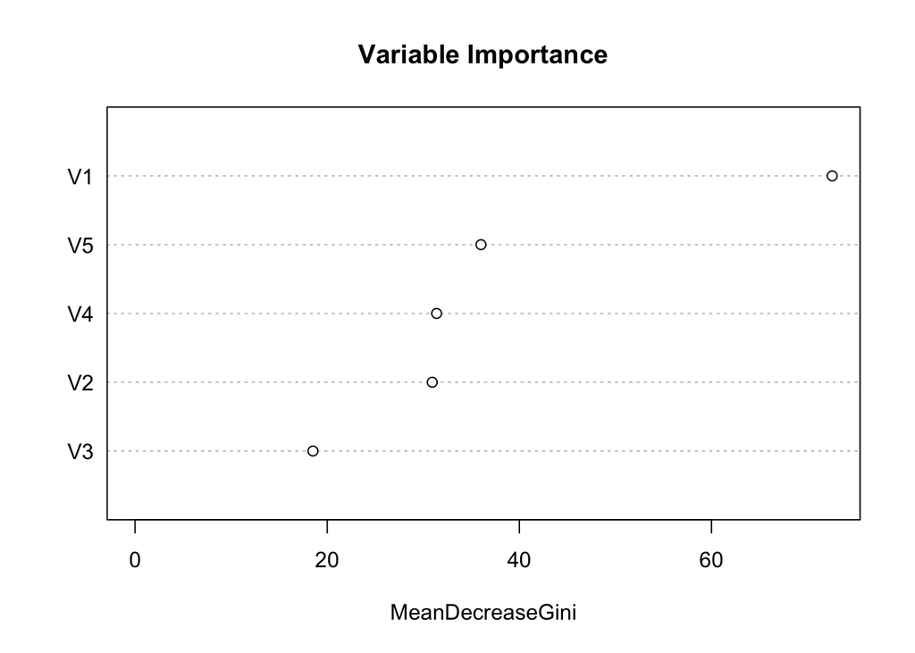

```r
varImpPlot(rf_model, main = "Variable Importance")
```

This “Variable Importance” chart shows how important different factors (V1, V2, V3, V4, V5) are in a model, probably using a decision tree or random forest method. The x-axis shows “MeanDecreaseGini,” which tells us how much each variable helps the model make accurate predictions. Higher numbers mean that the variable is more important. In this case, V1 is the most important, then comes V5, followed by V4, V2, and V3, which is the least important. This chart shows that V1 is the most important factor for predicting the result, while V3 is the least important.